# Lab_5

Lindley Slipetz

2/25/2021

### Load packages and data

```r
library(tidyverse)
#install.packages("wesanderson")
library(wesanderson)
```

```r
load("G:\\My Drive\\DataScience\\Lab_04\\data\\dennys.rda")
load("G:\\My Drive\\DataScience\\Lab_04\\data\\laquinta.rda")
```

### Exercise 1

```r
dn_ak <- dennys %>%
  filter(state == "AK")
nrow(dn_ak)
```

```
## [1] 3
```

There are 3 dennys in Alaska.

### Exercise 2

```r
lq_ak <- laquinta %>%
  filter(state == "AK")
nrow(lq_ak)
```

```
## [1] 2
```

There are 2 laquintas in alaska.

### Exercise 3

We need to calculate 6 distances.

### Exercise 4

```r
dn_lq_ak <- full_join(dn_ak, lq_ak, by = "state")
dn_lq_ak
```

```
## # A tibble: 6 x 11
##   address.x city.x state zip.x longitude.x latitude.x address.y city.y zip.y
##   <chr>     <chr>  <chr> <chr>       <dbl>      <dbl> <chr>     <chr>  <chr>
## 1 2900 Den~ Ancho~ AK    99503       -150.       61.2 3501 Min~ "\nAn~ 99503
## 2 2900 Den~ Ancho~ AK    99503       -150.       61.2 4920 Dal~ "\nFa~ 99709
## 3 3850 Deb~ Ancho~ AK    99508       -150.       61.2 3501 Min~ "\nAn~ 99503
## 4 3850 Deb~ Ancho~ AK    99508       -150.       61.2 4920 Dal~ "\nFa~ 99709
## 5 1929 Air~ Fairb~ AK    99701       -148.       64.8 3501 Min~ "\nAn~ 99503
## 6 1929 Air~ Fairb~ AK    99701       -148.       64.8 4920 Dal~ "\nFa~ 99709
## # ... with 2 more variables: longitude.y <dbl>, latitude.y <dbl>
```

There are 6 observations in the dataframe. The variables are address, city, state, zip, longitude, latitude for both the x and the y datasets.

### Exercise 5

We use mutate() to add a new variable to the dataframe while keeping the existing variables.

```r
haversine <- function(long1, lat1, long2, lat2, round = 3) {
  # convert to radians
  long1 = long1 * pi / 180
  lat1  = lat1  * pi / 180
  long2 = long2 * pi / 180
  lat2  = lat2  * pi / 180

  R = 6371 # Earth mean radius in km

  a = sin((lat2 - lat1)/2)^2 + cos(lat1) * cos(lat2) * sin((long2 - long1)/2)^2
  d = R * 2 * asin(sqrt(a))

  return( round(d,round) ) # distance in km
}
```

###Exercise 6

```r
dn_lq_ak <- dn_lq_ak %>%
  mutate(distance = haversine(longitude.x, latitude.x, longitude.y, latitude.y, round = 3))
```

### Exercise 7

```r
dn_lq_ak_mindist <- dn_lq_ak %>%
  group_by(address.x) %>%
  summarise(closest = min(distance))
```

### Exercise 8

[figure not shown]

```r
dn_lq_ak_mindist %>%
ggplot(mapping = aes(y = closest, x = reorder(address.x, -closest))) +
  geom_bar(stat="identity") +
  labs(title = "Closest dennys and laquintas-Alaska", y = "Closest", x = "Address")+
  scale_colour_grey(start = 0, end = .7) +
  theme_bw()
```

```r
dn_lq_ak_mindist %>%
  summary(closest)
```

```
##   address.x            closest
##  Length:3           Min.   :2.035
##  Class :character   1st Qu.:3.616
##  Mode  :character   Median :5.197
##                     Mean   :4.410
##                     3rd Qu.:5.598
##                     Max.   :5.998
```

The mean closest distance is 4.410. The minimym is 2.035 and the maximum is 5.998. The distribution has two bars that are nearly equal with one that is much smaller. As I have it arranged, it’s skewed to the right, but that’s an artifact of how I’ve arranged the data.

### Exercise 9

```r
dn_nc <- dennys %>%
  filter(state == "NC")
nrow(dn_nc)
```

```
## [1] 28
```

There are 28 dennys in North Carolina.

```r
lq_nc <- laquinta %>%
  filter(state == "NC")
nrow(lq_nc)
```

```
## [1] 12
```

There are 12 laquintas in North Carolina.

```r
dn_lq_nc <- full_join(dn_nc, lq_nc, by = "state")
dn_lq_nc
```

```
## # A tibble: 336 x 11
##    address.x city.x state zip.x longitude.x latitude.x address.y city.y zip.y
##    <chr>     <chr>  <chr> <chr>       <dbl>      <dbl> <chr>     <chr>  <chr>
##  1 1 Regent~ Ashev~ NC    28806       -82.6       35.6 165 Hwy ~ "\nBo~ 28607
##  2 1 Regent~ Ashev~ NC    28806       -82.6       35.6 3127 Slo~ "\nCh~ 28208
##  3 1 Regent~ Ashev~ NC    28806       -82.6       35.6 4900 Sou~ "\nCh~ 28217
##  4 1 Regent~ Ashev~ NC    28806       -82.6       35.6 4414 Dur~ "\nDu~ 27707
##  5 1 Regent~ Ashev~ NC    28806       -82.6       35.6 1910 Wes~ "\nDu~ 27713
##  6 1 Regent~ Ashev~ NC    28806       -82.6       35.6 1201 Lan~ "\nGr~ 27407
##  7 1 Regent~ Ashev~ NC    28806       -82.6       35.6 1607 Fai~ "\nCo~ 28613
##  8 1 Regent~ Ashev~ NC    28806       -82.6       35.6 191 Cres~ "\nCa~ 27518
##  9 1 Regent~ Ashev~ NC    28806       -82.6       35.6 2211 Sum~ "\nRa~ 27612
## 10 1 Regent~ Ashev~ NC    28806       -82.6       35.6 1001 Aer~ "\nMo~ 27560
## # ... with 326 more rows, and 2 more variables: longitude.y <dbl>,
## #   latitude.y <dbl>
```

```r
dn_lq_nc <- dn_lq_nc %>%
  mutate(distance = haversine(longitude.x, latitude.x, longitude.y, latitude.y, round = 3))
```

```r
dn_lq_nc_mindist <- dn_lq_nc %>%
  group_by(address.x) %>%
  summarise(closest = min(distance))
```

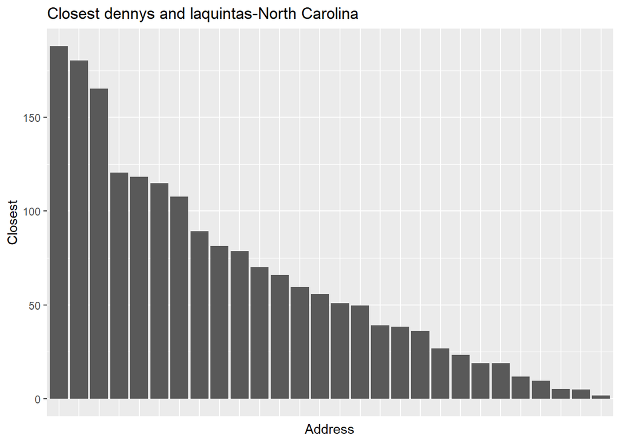

```r
dn_lq_nc_mindist %>%
ggplot(mapping = aes(y = closest, x = reorder(address.x, -closest))) +
  geom_bar(stat="identity") +
  labs(title = "Closest dennys and laquintas-North Carolina", y = "Closest", x = "Address")+
  scale_colour_grey(start = 0, end = .7) +
  theme(axis.text.x=element_blank(),
        axis.ticks.x=element_blank())
```

```r
dn_lq_nc_mindist %>%
  summary(closest)
```

```
##   address.x            closest
##  Length:28          Min.   :  1.779
##  Class :character   1st Qu.: 22.388
##  Mode  :character   Median : 53.456
##                     Mean   : 65.444
##                     3rd Qu.: 93.985
##                     Max.   :187.935
```

The minimum distance is 1.779 which is less than the minimum distance for Alaska. The maximum distance is 187.935 and the mean is 65.444 which are both much greater than the corresponding Alaska values. The graph is skewed to the right which is again an artifact of the code. There’s a cluster of distances above 150, and most of the data is below 75.

### Exercise 10

```r
dn_tx <- dennys %>%
  filter(state == "TX")
nrow(dn_tx)
```

```
## [1] 200
```

There are 200 dennys in Texas.

```r
lq_tx <- laquinta %>%
  filter(state == "TX")
nrow(lq_tx)
```

```
## [1] 237
```

There are 237 laquintas in Texas.

```r
dn_lq_tx <- full_join(dn_tx, lq_tx, by = "state")
dn_lq_tx
```

```
## # A tibble: 47,400 x 11
##    address.x city.x state zip.x longitude.x latitude.x address.y city.y zip.y
##    <chr>     <chr>  <chr> <chr>       <dbl>      <dbl> <chr>     <chr>  <chr>
##  1 120 East~ Abile~ TX    79601       -99.6       32.4 3018 Cat~ "\nAb~ 79606
##  2 120 East~ Abile~ TX    79601       -99.6       32.4 3501 Wes~ "\nAb~ 79601
##  3 120 East~ Abile~ TX    79601       -99.6       32.4 14925 La~ "\nAd~ 75254
##  4 120 East~ Abile~ TX    79601       -99.6       32.4 909 East~ "\nAl~ 78516
##  5 120 East~ Abile~ TX    79601       -99.6       32.4 2400 Eas~ "\nAl~ 78332
##  6 120 East~ Abile~ TX    79601       -99.6       32.4 1220 Nor~ "\nAl~ 75013
##  7 120 East~ Abile~ TX    79601       -99.6       32.4 1165 Hwy~ "\nAl~ 76009
##  8 120 East~ Abile~ TX    79601       -99.6       32.4 880 Sout~ "\nAl~ 77511
##  9 120 East~ Abile~ TX    79601       -99.6       32.4 1708 Int~ "\nAm~ 79103
## 10 120 East~ Abile~ TX    79601       -99.6       32.4 9305 Eas~ "\nAm~ 79118
## # ... with 47,390 more rows, and 2 more variables: longitude.y <dbl>,
## #   latitude.y <dbl>
```

```r
dn_lq_tx <- dn_lq_tx %>%
  mutate(distance = haversine(longitude.x, latitude.x, longitude.y, latitude.y, round = 3))
```

```r
dn_lq_tx_mindist <- dn_lq_tx %>%
  group_by(address.x) %>%
  summarise(closest = min(distance))
```

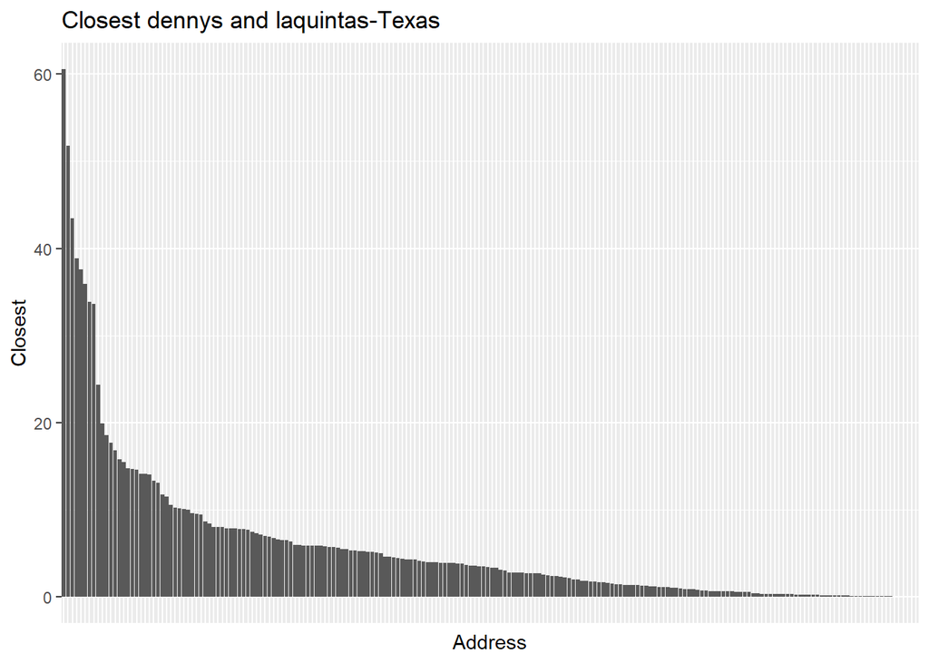

```r
dn_lq_tx_mindist %>%
ggplot(mapping = aes(y = closest, x = reorder(address.x, -closest))) +
  geom_bar(stat="identity") +
  labs(title = "Closest dennys and laquintas-Texas", y = "Closest", x = "Address")+
  scale_colour_grey(start = 0, end = .7) +
  theme(axis.text.x=element_blank(),
        axis.ticks.x=element_blank())
```

```r
dn_lq_tx_mindist %>%
  summary(closest)
```

```
##   address.x            closest
##  Length:200         Min.   : 0.0160
##  Class :character   1st Qu.: 0.7305
##  Mode  :character   Median : 3.3715
##                     Mean   : 5.7918
##                     3rd Qu.: 6.6303
##                     Max.   :60.5820
```

The minimum distance (0.0160) is the lowest out of all three states so far. The maximum (60.5820) and mean (5.7918) are between Alaska (lower) and North Carolina (higher). In the graph, we see a cluster on the left with distances above 30. We also see that most of the distances are below 20.

### Exercise 11

```r
dn_il <- dennys %>%
  filter(state == "IL")
nrow(dn_il)
```

```
## [1] 56
```

There are 56 dennys in Illinois.

```r
lq_il <- laquinta %>%
  filter(state == "IL")
nrow(lq_il)
```

```
## [1] 17
```

There are 17 laquintas in Illinois.

```r
dn_lq_il <- full_join(dn_il, lq_il, by = "state")
dn_lq_il
```

```
## # A tibble: 952 x 11
##    address.x city.x state zip.x longitude.x latitude.x address.y city.y zip.y
##    <chr>     <chr>  <chr> <chr>       <dbl>      <dbl> <chr>     <chr>  <chr>
##  1 140 Race~ Alort~ IL    62205       -90.1       38.6 1900 Cen~ "\nCh~ 61820
##  2 140 Race~ Alort~ IL    62205       -90.1       38.6 One Sout~ "\nCh~ 60606
##  3 140 Race~ Alort~ IL    62205       -90.1       38.6 5688 Nor~ "\nGu~ 60031
##  4 140 Race~ Alort~ IL    62205       -90.1       38.6 4900A S.~ "\nCh~ 60615
##  5 140 Race~ Alort~ IL    62205       -90.1       38.6 2000 Sou~ "\nBa~ 60015
##  6 140 Race~ Alort~ IL    62205       -90.1       38.6 1900 Eas~ "\nEl~ 60007
##  7 140 Race~ Alort~ IL    62205       -90.1       38.6 1 South ~ "\nOa~ 60181
##  8 140 Race~ Alort~ IL    62205       -90.1       38.6 7255 Wes~ "\nTi~ 60477
##  9 140 Race~ Alort~ IL    62205       -90.1       38.6 855 79th~ "\nWi~ 60527
## 10 140 Race~ Alort~ IL    62205       -90.1       38.6 6 Gatewa~ "\nCo~ 62234
## # ... with 942 more rows, and 2 more variables: longitude.y <dbl>,
## #   latitude.y <dbl>
```

```r
dn_lq_il <- dn_lq_il %>%
  mutate(distance = haversine(longitude.x, latitude.x, longitude.y, latitude.y, round = 3))
```

```r
dn_lq_il_mindist <- dn_lq_il %>%
  group_by(address.x) %>%
  summarise(closest = min(distance))
```

[figure not shown]

```r
dn_lq_tx_mindist %>%
ggplot(mapping = aes(y = closest, x = reorder(address.x, -closest))) +
  geom_bar(stat="identity") +
  labs(title = "Closest dennys and laquintas-Illinois", y = "Closest", x = "Address")+
  scale_colour_grey(start = 0, end = .7) +
  theme(axis.text.x=element_blank(),
        axis.ticks.x=element_blank())
```

```r
dn_lq_il_mindist %>%
  summary(closest)
```

```
##   address.x            closest
##  Length:56          Min.   :  0.149
##  Class :character   1st Qu.:  3.113
##  Mode  :character   Median : 12.405
##                     Mean   : 23.212
##                     3rd Qu.: 31.954
##                     Max.   :113.267
```

### Exercise 12

I think the Mitch Hedburg joke holds most for Alaska. Although Alaska does not have the closest dennys-laquinta pair (that’s in Texas), it has the lowest mean and the lowest maximum. The lowest mean tells us that dennys and laquintas are generally closer together in Alaska. The lowest maximum tells us that even the dennys-laquintas pairs that are far apart are still closer together than the far apart laquintas and dennys in other states. Perhaps Mitch Hedburg first told this joke at Chilkoot Charlie’s on a Sunday or Wednesday night (…yes, I looked up comedy clubs in Alaska. Chilkoot Charlie’s was one of the first results and they have stand up on Sundays and Wednesdays).